# MB1 CDI Follow-up Confirmatory Analysis

The ManyBabies Analysis Team

Wed Jun 16 18:09:45 2021

# 1 Introduction

In this script, we go through all the pre-registered proposed analyses. As a reminder, the main research questions where as follows:

1. To what extent does infants#’ preference for IDS as measured in a laboratory setting predict their vocabulary at 18 and 24 months?
2. Does the relation between IDS preference and vocabulary size change over development?
3. Are there systematic differences in the strength of this relationship across the language communities in our sample?

We first present the main “sample theory based” analyses (also known as frequentist), separately on the North American and UK samples in parallel to answer our first two research questions, then on the total dataset to answer our third research question. We then provide additional Bayesian statistics where a null effect was found, as specified in the pre-registration.

```r
# Library imports, general settings ==============
library(tidyverse); library(egg)
library(knitr)
library(lme4); library(lmerTest); library(simr)
# As in our discussion with Mike, we will use lmerTest for calculating p values
# in the mixed-effects models (noted as a deviation)
library(brms); library(rstan)
library(future)
plan(multicore, workers = 8) # Swap to multiprocess if running from Rstudio

# Load model comparison functions
source("helper/lrtests.R")

# Deal with package priority issues
select <- dplyr::select

theme_set(theme_bw(base_size = 10))
options("future" = T)
#knitr::opts_chunk$set(cache = TRUE)

# Read data ======================================
col_types <- cols(
  labid = col_factor(),
  subid = col_factor(),
  subid_unique = col_factor(),
  CDI.form = col_factor(),
  CDI.nwords = col_integer(),
  CDI.prop = col_number(),
  CDI.agerange = col_factor(),
  CDI.agedays = col_integer(),
  CDI.agemin = col_integer(),
  CDI.agemax = col_integer(),
  vocab_nwords = col_integer(),
  standardized.score.CDI = col_character(),
  standardized.score.CDI.num = col_number(),
  IDS_pref = col_number(),
  language = col_factor(),
  language_zone = col_factor(),
  CDI.error = col_logical(),
  Notes = col_character(),
  trial_order = col_factor(),
  method = col_factor(),
  age_days = col_integer(),
  age_mo = col_number(),
  age_group = col_factor(),
  nae = col_logical(),
  gender = col_factor(),
  second_session = col_logical()
)
data.total <- read_csv("data/02b_processed.csv", col_types = col_types)
# TODO: add saved results
```

Before moving on with the analysis, we have to ready the data by (a) checking for colinearity between `z_age_months` and `CDI.z_age_months` and correcting this if necessary, and (b) setting up the contrasts described in our data analysis.

## 1.1 Colinearity check

First, we run a Kappa test on the possibility of colinearity between `z_age_months` and `CDI.z_age_months`.

```r
# Run kappa test
k.age_months <- model.matrix(~ z_age_months + CDI.z_age_months, data = data.total) %>%
  kappa(exact = T)
```

With a value of 3.1980728, we do not have a colinearity issue and can proceed with the data analysis as planned (The criteria of indicating colinearity is that kappa > 10).

## 1.2 Contrast Setups

We need `gender` as an effect-coded factor, and `method` as a deviation-coded factor. This is achieved in R by using the `contr.sum()` function with the number of levels for each factor. Notably, when subsetting the UK sample, only two levels of `method` out of the three in total were left.

```r
# Set contrasts on the total dataset =============
contrasts(data.total$gender) <- contr.sum(2)
contrasts(data.total$method) <- contr.sum(3)

# Create sub-datasets, with contrasts ============
## NAE
data.nae <- data.total %>% subset(language_zone == "NAE") %>% droplevels()
contrasts(data.nae$gender) <- contr.sum(2)
contrasts(data.nae$method) <- contr.sum(3)

## UK
data.uk <- data.total %>% subset(language_zone == "British") %>% droplevels()
contrasts(data.uk$gender) <- contr.sum(2)
contrasts(data.uk$method) <- contr.sum(2) #note that UK sample has only 2 levels, so sum of zero contrasts set to 2 levels

## Other
data.other <- data.total %>% subset(language_zone == "Other") %>% droplevels()
contrasts(data.other$gender) <- contr.sum(2)
contrasts(data.other$method) <- contr.sum(3)
```

# 2 Descriptive Statistics

We first assess the amount of data we have overall per condition and their shape overall.

```r
data.total %>%
  group_by(language_zone, CDI.agerange, method, gender) %>%
  summarise(N = n(), age = mean(CDI.agedays), sd = sd(CDI.agedays)) %>%
  kable()
```

| language_zone | CDI.agerange | method | gender | N | age | sd |
| --- | --- | --- | --- | --- | --- | --- |
| British | 18 | singlescreen | F | 24 | 551.2083 | 10.741950 |
| British | 18 | singlescreen | M | 24 | 550.5000 | 13.497182 |
| British | 18 | eyetracking | F | 9 | 548.5556 | 9.139353 |
| British | 18 | eyetracking | M | 11 | 547.8182 | 10.147100 |
| British | 24 | singlescreen | F | 18 | 741.6111 | 13.128948 |
| British | 24 | singlescreen | M | 15 | 745.0667 | 15.549307 |
| British | 24 | eyetracking | F | 13 | 731.5385 | 12.162890 |
| British | 24 | eyetracking | M | 5 | 737.8000 | 8.228001 |
| Other | 18 | singlescreen | F | 11 | 541.5455 | 7.160498 |
| Other | 18 | singlescreen | M | 13 | 544.3077 | 6.663140 |
| Other | 18 | eyetracking | F | 26 | 556.0769 | 14.133430 |
| Other | 18 | eyetracking | M | 30 | 560.8333 | 16.128970 |
| Other | 18 | hpp | F | 38 | 549.0526 | 10.812774 |
| Other | 18 | hpp | M | 38 | 555.1579 | 13.664961 |
| Other | 24 | singlescreen | F | 10 | 731.3000 | 14.802777 |
| Other | 24 | singlescreen | M | 12 | 721.1667 | 13.888081 |
| Other | 24 | eyetracking | F | 28 | 730.1786 | 9.996494 |
| Other | 24 | eyetracking | M | 25 | 730.1600 | 7.711896 |
| Other | 24 | hpp | F | 45 | 730.7333 | 17.357733 |
| Other | 24 | hpp | M | 35 | 730.5143 | 15.849237 |
| NAE | 18 | singlescreen | F | 19 | 554.9474 | 20.780530 |
| NAE | 18 | singlescreen | M | 14 | 581.2143 | 24.925052 |
| NAE | 18 | eyetracking | F | 1 | 549.0000 | NA |
| NAE | 18 | hpp | F | 64 | 557.9375 | 22.801333 |
| NAE | 18 | hpp | M | 66 | 556.1667 | 22.762035 |
| NAE | 24 | singlescreen | F | 23 | 737.1739 | 26.604258 |
| NAE | 24 | singlescreen | M | 20 | 739.6000 | 21.352678 |
| NAE | 24 | eyetracking | F | 2 | 756.5000 | 34.648232 |
| NAE | 24 | eyetracking | M | 1 | 745.0000 | NA |
| NAE | 24 | hpp | F | 58 | 731.6897 | 28.149480 |
| NAE | 24 | hpp | M | 65 | 726.2769 | 27.133068 |

More detailed information about Descriptive Statistics

```r
#number of lab
data.total %>%
  select(labid, language_zone) %>%
  unique() %>%
  group_by(language_zone) %>%
  count()
```

```
## # A tibble: 3 x 2
## # Groups:   language_zone [3]
##   language_zone     n
##   <fct>         <int>
## 1 British           4
## 2 Other             8
## 3 NAE               9
```

```r
data.total %>%
  group_by(language_zone, CDI.agerange) %>%
  summarize(N = n())
```

```
## # A tibble: 6 x 3
## # Groups:   language_zone [3]
##   language_zone CDI.agerange     N
##   <fct>         <fct>        <int>
## 1 British       18              68
## 2 British       24              51
## 3 Other         18             156
## 4 Other         24             155
## 5 NAE           18             164
## 6 NAE           24             169
```

```r
# age range in each age group and language zone
data.total %>%
  select(subid, language_zone, CDI.agedays, CDI.agerange) %>%
  unique() %>%
  group_by(language_zone, CDI.agerange) %>%
  summarize(age_min = (min(CDI.agedays)/365.25*12),
            age_max = (max(CDI.agedays)/365.25*12))
```

```
## # A tibble: 6 x 4
## # Groups:   language_zone [3]
##   language_zone CDI.agerange age_min age_max
##   <fct>         <fct>          <dbl>   <dbl>
## 1 British       18              17.4    19.2
## 2 British       24              23.4    25.1
## 3 Other         18              17.4    19.5
## 4 Other         24              22.5    25.2
## 5 NAE           18              16.1    20.0
## 6 NAE           24              22.1    25.9
```

We then assess the data per lab in terms of sample size and CDI score (vocabulary size, for consistency between language zones).

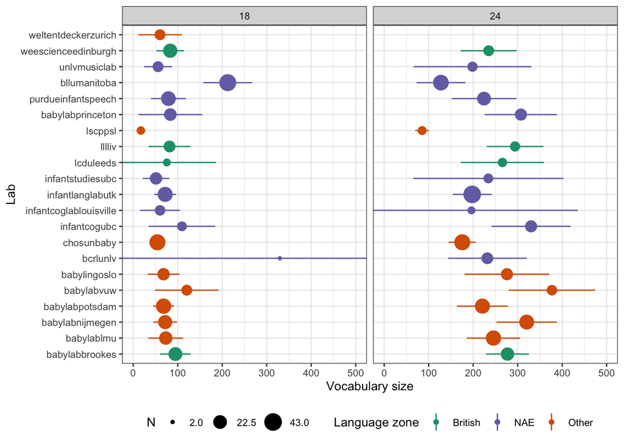

```r
by_lab <- data.total %>%
  group_by(labid, language_zone, CDI.agerange) %>%
  mutate(tested = n_distinct(subid_unique)) %>%
  select(labid, language_zone, CDI.agerange, tested, vocab_nwords) %>%
  nest(scores = vocab_nwords) %>%
  mutate(model = map(scores, ~ lm(vocab_nwords ~ 1, data = .x)),
         ci = map(model, confint)) %>%
  transmute(tested = tested,
            mean = map_dbl(model, ~ coefficients(.x)[[1]]),
            ci_lower = map_dbl(ci, 1),
            ci_upper = map_dbl(ci, 2)) %>%
  arrange(language_zone) %>%
  rownames_to_column()

# TODO: find a way to group by language zone?
ggplot(by_lab,
       aes(x = labid, colour = language_zone,
           y = mean, ymin = ci_lower, ymax = ci_upper)) +
  geom_linerange() +
  geom_point(aes(size = tested)) +
  facet_grid(cols = vars(CDI.agerange), scales = "free") + coord_flip(ylim = c(0, 500)) +
  xlab("Lab") + ylab("Vocabulary size") +
  scale_colour_brewer(palette = "Dark2", name = "Language zone",
                      breaks = c("British", "NAE", "Other")) +
  scale_size_continuous(name = "N", breaks = function(x) c(min(x), mean(x), max(x))) +
  theme(legend.position = "bottom")
```

# 3 Sample Theory Based Statistics

## 3.1 Simple Correlation

First, we want to assess quickly if there is a direct correlation between IDS preference and CDI score, computing a Pearson#’s product-moment correlation. We use standardized CDI scores for the North American sample, and raw scores for the British sample. [NOTE FROM MELANIE: I’m not sure this makes sense to do with the raw UK scores - since we’re collapsing across 18 and 24 month data and the data aren#’t standardized by age.].

```r
# Statistics =====================================
## North American Sample
test.pearson.nae <- cor.test(data.nae$IDS_pref,
                             data.nae$z_standardized_CDI,
                             alternative = "two.sided", method = "pearson")
## UK Sample
test.pearson.uk <- cor.test(data.uk$IDS_pref,
                            data.uk$z_vocab_nwords,
                            alternative = "two.sided", method = "pearson")
```

Plots for correlation

[figure not shown]

```r
## North American Sample
### Get correlation value for annotation
cor_text <- "paste(italic(R)^2, \" =\")"
cor_value <- round(test.pearson.nae$estimate, 3)

### Build plot
plot.pearson.nae <- data.nae %>%
  ggplot(aes(x = IDS_pref,
             y = standardized.score.CDI.num)) +
  xlab("IDS preference") + ylab("Standardized CDI score") +
  geom_point() +
  geom_smooth(method = lm) +
  annotate("text", x = -.9, y = 51, parse = T, size = 4,
           label = paste(cor_text, cor_value, sep = "~"))

## UK Sample
cor_value <- round(test.pearson.uk$estimate, 3)
plot.pearson.uk <- data.uk %>%
  ggplot(aes(x = IDS_pref,
             y = vocab_nwords)) +
  xlab("IDS preference") + ylab("Vocabulary size (in words)") +
  geom_point() +
  geom_smooth(method = lm) +
  annotate("text", x = .8, y = 150, parse = T, size = 4,
           label = paste(cor_text, cor_value, sep = "~"))

# Global plot
plot.pearson <- ggarrange(plot.pearson.nae, plot.pearson.uk, ncol = 2)
```

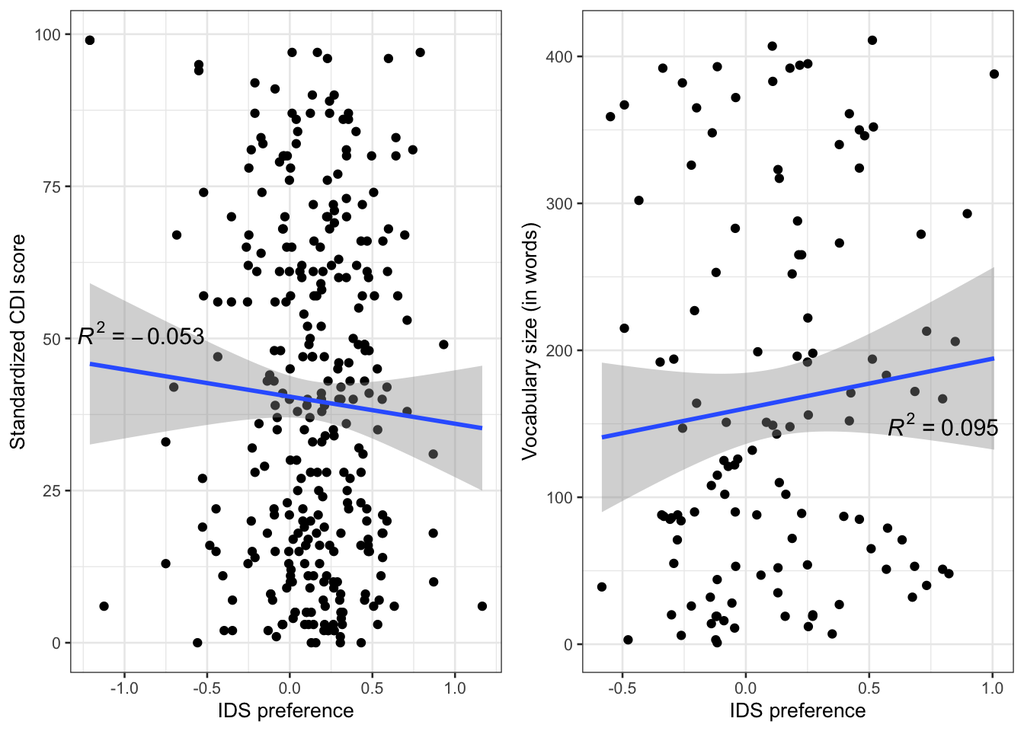

```r
plot.pearson
```

```r
ggsave("plots/corr_plot.pdf", plot.pearson,
       units = "mm", width = 180, height = 100, dpi = 1000)
```

We see no obvious direct link between IDS prefernce and CDI score here. However, an effect might appear once we take into account various factors that might interact with IDS preference and/or CDI score. We can also first enhance these plots with information about the age group at which infants were tested (18- or 24-month-old), using vocabulary size to better compare the NAE and UK samples.

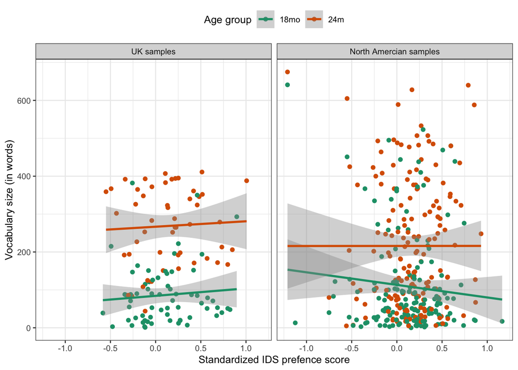

```r
plot.age_group <- data.total %>%
  subset(language_zone != "Other") %>%
  droplevels() %>%
  ggplot(aes(x = IDS_pref,
             y = vocab_nwords,
             colour = CDI.agerange)) +
  facet_wrap(vars(language_zone),
             labeller = as_labeller(c("British" = "UK samples",
                                      "NAE" = "North Amercian samples"))) +
  xlab("Standardized IDS prefence score") + ylab("Vocabulary size (in words)") + theme(legend.position = "top") +
  geom_point() +
  geom_smooth(method = lm) +
  scale_colour_brewer(palette = "Dark2", name = "Age group",
                      breaks = c("18", "24"),
                      labels = c("18mo", "24m"))
ggsave("plots/scatter_age.pdf", plot.age_group,
       units = "mm", width = 180, height = 100, dpi = 1000)
(plot.age_group)
```

## 3.2 Mixed-Effects Model by Language Zone

Here, we run a mixed-effects model including only theoretically motivated effects, as described in the pre-registration. We start with the full model bellow, simplifying the random effects structure until it converges.

NAE full model

```r
# Run models =====================================
## NAE
lmer.full.nae <- lmer(standardized.score.CDI.num ~ CDI.z_age_months + gender +
                        z_age_months + method + IDS_pref +
                        IDS_pref:method + IDS_pref:CDI.z_age_months + IDS_pref:z_age_months +
                        (1 | labid),
                      data = data.nae)

summary(lmer.full.nae)
```

```
## Linear mixed model fit by REML. t-tests use Satterthwaite's method [
## lmerModLmerTest]
## Formula:
## standardized.score.CDI.num ~ CDI.z_age_months + gender + z_age_months +
##     method + IDS_pref + IDS_pref:method + IDS_pref:CDI.z_age_months +
##     IDS_pref:z_age_months + (1 | labid)
##    Data: data.nae
##
## REML criterion at convergence: 2861
##
## Scaled residuals:
##     Min      1Q  Median      3Q     Max
## -1.7649 -0.8396 -0.1049  0.7743  2.3582
##
## Random effects:
##  Groups   Name        Variance Std.Dev.
##  labid    (Intercept)  78.28    8.847
##  Residual             752.79   27.437
## Number of obs: 307, groups:  labid, 8
##
## Fixed effects:
##                            Estimate Std. Error        df t value Pr(>|t|)
## (Intercept)                36.47406    6.32770  32.44637   5.764 2.05e-06 ***
## CDI.z_age_months           -0.08547    0.60532 294.71791  -0.141    0.888
## gender1                    -1.07741    1.61552 291.53707  -0.667    0.505
## z_age_months                0.10251    0.60682 170.47454   0.169    0.866
## method1                     4.72402    6.04969 107.21841   0.781    0.437
## method2                    -8.28549   10.68414 239.80703  -0.775    0.439
## IDS_pref                  -36.58820   23.08570 289.74473  -1.585    0.114
## method1:IDS_pref           27.84822   23.61831 290.27716   1.179    0.239
## method2:IDS_pref          -58.54287   46.03821 289.28918  -1.272    0.205
## CDI.z_age_months:IDS_pref   1.15753    1.67303 290.78963   0.692    0.490
## z_age_months:IDS_pref       1.78245    1.73910 292.19209   1.025    0.306
## ---
## Signif. codes:  0 '***' 0.001 '**' 0.01 '*' 0.05 '.' 0.1 ' ' 1
##
## Correlation of Fixed Effects:
##             (Intr) CDI.z__ gendr1 z_g_mn methd1 methd2 IDS_pr m1:IDS m2:IDS
## CDI.z_g_mnt -0.094
## gender1     -0.074  0.040
## z_age_mnths  0.056 -0.061  -0.118
## method1     -0.592  0.046   0.026  0.122
## method2      0.812 -0.085  -0.084  0.016 -0.787
## IDS_pref    -0.314  0.047   0.026 -0.047  0.310 -0.357
## mthd1:IDS_p  0.296 -0.059  -0.014  0.043 -0.322  0.352 -0.928
## mthd2:IDS_p -0.307  0.065   0.047 -0.059  0.316 -0.369  0.969 -0.972
## CDI.__:IDS_  0.029 -0.406  -0.030  0.022 -0.063  0.061 -0.078  0.038 -0.072
## z_g_mn:IDS_ -0.044  0.078   0.131 -0.368 -0.014 -0.044  0.031 -0.063  0.121
##             CDI.__:
## CDI.z_g_mnt
## gender1
## z_age_mnths
## method1
## method2
## IDS_pref
## mthd1:IDS_p
## mthd2:IDS_p
## CDI.__:IDS_
## z_g_mn:IDS_ -0.097
```

```r
full.nae_pvalue <- anova(lmer.full.nae) %>%
  as_tibble(rownames = "Parameter") #this gives us the Type III p values

# ==========
# Sequentially removed random effects:
# IDS_pref:z_age_months
# IDS_pref:CDI.z_age_months
# IDS_pref:method
# IDS_pref
# method
# z_age_months
# gender
# CDI.z_age_months
#==========
```

UK full model

```r
lmer.full.uk <- lmer(vocab_nwords ~ CDI.z_age_months + gender +
                       z_age_months + method + IDS_pref +
                       IDS_pref:method + IDS_pref:CDI.z_age_months + IDS_pref:z_age_months +
                       (1 | labid),
                     data = data.uk)

summary(lmer.full.uk)
```

```
## Linear mixed model fit by REML. t-tests use Satterthwaite's method [
## lmerModLmerTest]
## Formula: vocab_nwords ~ CDI.z_age_months + gender + z_age_months + method +
##     IDS_pref + IDS_pref:method + IDS_pref:CDI.z_age_months +
##     IDS_pref:z_age_months + (1 | labid)
##    Data: data.uk
##
## REML criterion at convergence: 1342.7
##
## Scaled residuals:
##     Min      1Q  Median      3Q     Max
## -2.0447 -0.6691 -0.0987  0.5147  3.5513
##
## Random effects:
##  Groups   Name        Variance Std.Dev.
##  labid    (Intercept)  148.7   12.20
##  Residual             7856.7   88.64
## Number of obs: 119, groups:  labid, 4
##
## Fixed effects:
##                           Estimate Std. Error      df t value Pr(>|t|)
## (Intercept)                174.008     11.521   3.138  15.103 0.000491 ***
## CDI.z_age_months            28.628      2.824 109.795  10.138  < 2e-16 ***
## gender1                     17.578      8.623 109.015   2.039 0.043906 *
## z_age_months                -6.034      3.042 101.094  -1.984 0.050013 .
## method1                    -16.483     12.871   4.413  -1.281 0.263499
## IDS_pref                     4.072     24.014 109.842   0.170 0.865669
## method1:IDS_pref             4.413     27.446 109.729   0.161 0.872550
## CDI.z_age_months:IDS_pref    0.600      7.877 108.111   0.076 0.939422
## z_age_months:IDS_pref        1.143      8.291 109.890   0.138 0.890629
## ---
## Signif. codes:  0 '***' 0.001 '**' 0.01 '*' 0.05 '.' 0.1 ' ' 1
##
## Correlation of Fixed Effects:
##             (Intr) CDI.z__ gendr1 z_g_mn methd1 IDS_pr m1:IDS CDI.__:
## CDI.z_g_mnt  0.137
## gender1     -0.021 -0.099
## z_age_mnths -0.026 -0.106  -0.001
## method1     -0.297 -0.075  -0.029  0.454
## IDS_pref    -0.313 -0.088  -0.112  0.068  0.180
## mthd1:IDS_p  0.164  0.122  -0.012 -0.119 -0.264 -0.167
## CDI.__:IDS_ -0.123 -0.328   0.076  0.063  0.103  0.101 -0.195
## z_g_mn:IDS_  0.021  0.095  -0.232 -0.360 -0.106 -0.119  0.493 -0.280
```

```r
full.uk_pvalue <- anova(lmer.full.uk) %>%
  as_tibble(rownames = "Parameter") #this gives us the Type III p values

#==========
# Sequentially removed random effects:
# IDS_pref:z_age_months
# IDS_pref:CDI.z_age_months
# IDS_pref:method
# IDS_pref
# method
# z_age_months
# gender
# CDI.z_age_months
```

We now want to check the statistical power of significant effects, and discard any models with significant effects that do not reach 80% power. This however leads to too many warnings of singularity issues on the model updates inherent to the `simr` power simulations, hence we cannot obtain satisfactory power estimates as pre-registered.

```r
check_pwr_uk_cdi_age <- simr::powerSim(lmer.full.uk, test = fixed("CDI.z_age_months", method = "z"), seed = 2, nsim = 1000, alpha = 0.05) #specify that Gender is the ixed effect that we are looking into

check_pwr_uk_cdi_age

check_pwr_uk_gender <- simr::powerSim(lmer.full.uk, test = fixed("gender", method = "z"), seed = 3, nsim = 1000, alpha = 0.05) #specify that Gender is the ixed effect that we are looking into

check_pwr_uk_gender
```

## 3.3 Combined Sample

For this combined analysis, we first need to restrain the age range for the NAE sample (previously ±2 months, now ±1.5 months).

```r
# Create dataset with British and NAE only
data.uk_nae <- data.total %>%
  subset(language_zone %in% c("British", "NAE")) %>%
  mutate(CDI.agemin = ifelse(language_zone == "NAE",
                             CDI.agemin + round(.5*365.25/12),
                             CDI.agemin),
         CDI.agemax = ifelse(language_zone == "NAE",
                             CDI.agemax - round(.5*365.25/12),
                             CDI.agemax)) %>%
  subset(!(CDI.agedays < CDI.agemin | CDI.agedays > CDI.agemax)) %>%
  droplevels()
# Create contrasts for analysis
contrasts(data.uk_nae$gender) <- contr.sum(2)
contrasts(data.uk_nae$method) <- contr.sum(3)
contrasts(data.uk_nae$language_zone) <- contr.sum(2)
```

We can then run the planned combined analysis adding the main effect and interactions of `language_zone`.

```r
lmer.full.uk_nae <- lmer(CDI.prop ~ CDI.z_age_months + language_zone + gender +
                           z_age_months + method + IDS_pref + IDS_pref:language_zone +
                           IDS_pref:method + IDS_pref:CDI.z_age_months + IDS_pref:z_age_months +
                           (1 + CDI.z_age_months | labid),
                         data = data.uk_nae)

summary(lmer.full.uk_nae)
```

```
## Linear mixed model fit by REML. t-tests use Satterthwaite's method [
## lmerModLmerTest]
## Formula: CDI.prop ~ CDI.z_age_months + language_zone + gender + z_age_months +
##     method + IDS_pref + IDS_pref:language_zone + IDS_pref:method +
##     IDS_pref:CDI.z_age_months + IDS_pref:z_age_months + (1 +
##     CDI.z_age_months | labid)
##    Data: data.uk_nae
##
## REML criterion at convergence: -21
##
## Scaled residuals:
##     Min      1Q  Median      3Q     Max
## -2.2245 -0.6694 -0.1837  0.4982  3.5339
##
## Random effects:
##  Groups   Name             Variance  Std.Dev. Corr
##  labid    (Intercept)      0.0020122 0.04486
##           CDI.z_age_months 0.0007413 0.02723  0.36
##  Residual                  0.0441247 0.21006
## Number of obs: 424, groups:  labid, 13
##
## Fixed effects:
##                             Estimate Std. Error         df t value Pr(>|t|)
## (Intercept)                 0.321001   0.020414   8.754057  15.724 1.02e-07 ***
## CDI.z_age_months            0.043337   0.008668  13.988032   4.999 0.000195 ***
## language_zone1              0.080835   0.025683   8.466121   3.147 0.012714 *
## gender1                     0.032968   0.010530 394.988464   3.131 0.001873 **
## z_age_months               -0.001686   0.003904 264.576872  -0.432 0.666306
## method1                    -0.010501   0.026027  14.799941  -0.403 0.692390
## method2                     0.003202   0.040000  12.158887   0.080 0.937509
## IDS_pref                    0.001938   0.037577 405.652214   0.052 0.958897
## language_zone1:IDS_pref     0.067205   0.053369 397.683802   1.259 0.208679
## method1:IDS_pref           -0.025488   0.050300 407.181386  -0.507 0.612627
## method2:IDS_pref           -0.049828   0.080961 405.756017  -0.615 0.538598
## CDI.z_age_months:IDS_pref   0.010718   0.010637 407.880904   1.008 0.314227
## z_age_months:IDS_pref      -0.004766   0.010327 401.531672  -0.462 0.644649
## ---
## Signif. codes:  0 '***' 0.001 '**' 0.01 '*' 0.05 '.' 0.1 ' ' 1
```

```
##
## Correlation matrix not shown by default, as p = 13 > 12.
## Use print(x, correlation=TRUE)  or
##     vcov(x)        if you need it
```

```r
combined.full.uk_nae_pvalue <- anova(lmer.full.uk_nae) %>%
  as_tibble(rownames = "Parameter") #this gives us the Type III p values

#==========
# Sequentially removed random effects:
# IDS_pref:z_age_months
# IDS_pref:CDI.z_age_months
# IDS_pref:method
# IDS_pref:language_zone
# IDS_pref
# method
# z_age_months
# gender
# language_zone
#==========
```

We then compute $p$-values, but leave out power estimates for those $p$-values as above. Again, we have a lot of singular fit issues for the power checks and decided not to remove parameters based on posthoc power analysis.

```r
check_pwr_combined_cdi_age <- simr::powerSim(lmer.full.uk_nae, test = fixed("CDI.z_age_months", method = "z"), seed = 2, nsim = 1000, alpha = 0.05) #specify that Gender is the ixed effect that we are looking into

check_pwr_combined_cdi_age

check_pwr_combined_lang_zone <- simr::powerSim(lmer.full.uk_nae, test = fixed("language_zone", method = "z"), seed = 3, nsim = 1000, alpha = 0.05) #specify that Gender is the ixed effect that we are looking into

check_pwr_combined_lang_zone

check_pwr_combined_gender <- simr::powerSim(lmer.full.uk_nae, test = fixed("gender", method = "z"), seed = 3, nsim = 1000, alpha = 0.05) #specify that Gender is the ixed effect that we are looking into

check_pwr_combined_gender
```

# 4 Bayesian Statistics

Given that the `frequentist#’ tests above did not discover any expected significant effects, we now run a Bayesian analysis, specifically Bayes factors (or $b$-values) from model comparisons, to determine whether our data provide evidence for a true null effect or merely fail to provide evidence either way.

We first run models on the separate UK and NAE samples.

First of all, we need to set up the priors for the Bayeisan analysis. In the RR, we said that we would use a Cauchy distribution for priors over fixed effects with normally distributed priors over random effect parameters."

## 4.1 Set up priors

Set up a really weak and not too informative prior

```r
prior <-c(set_prior("normal(10, 1)", class = "Intercept"), #we can't have negative CDI
              set_prior("cauchy(0, 1)", class = "b"), #all IVs have the same prior..
              set_prior("normal(0, 1)", class = "sd"))

prior_combined_mod <-c(set_prior("normal(10, 1)", class = "Intercept"),
              set_prior("cauchy(0, 1)", class = "b"), #all IVs have the same prior..
              set_prior("normal(0, 1)", class = "sd"),
              set_prior("lkj(2)", class = "L")) #adding this as there is a random slope and we need a correlation matrix prior between slope and intercept
```

Set up another prior that mainly changed the meaan for the fixed effect and see if there is big difference? Note: numbers changed but not to the extent that change BF conclusion.

```r
prior_big <-c(set_prior("normal(10, 1)", class = "Intercept"), #we can't have negative CDI
              set_prior("cauchy(10, 5)", class = "b"), #all IVs have the same prior..
              set_prior("normal(0, 1)", class = "sd"))

prior_combined_big <-c(set_prior("normal(10, 1)", class = "Intercept"),
              set_prior("cauchy(10, 5)", class = "b"), #all IVs have the same prior..
              set_prior("normal(0, 1)", class = "sd"),
              set_prior("lkj(2)", class = "L")) #adding this as there is a random slope and we need a correlation matrix prior between slope and intercept
```

We also try more informative prior.

## 4.2 NAE info prior

```r
prior_nae_1 <-c(set_prior("normal(50, 1)", class = "Intercept"), #note that nae's DV is percentile score, but I will assume at 18 months, the average is at 50 percentile
              set_prior("cauchy(5, 1)", class = "b", coef = "CDI.z_age_months"), #assume increase in 1 month may lead to 5 % percentile increase?
              set_prior("cauchy(-15, 5)", class = "b", coef = "gender1"), # female is the baseline, normally females know more words than males
              set_prior("cauchy(0, 1)", class = "b", coef = "IDS_pref"), #weak prior as don't know the effect of IDS preference to CDI score
              set_prior("cauchy(0, 1)", class = "b", coef = "method1"), #weak prior as methods related to the MB1 study shouldn't influence CDI scores
              set_prior("cauchy(0, 1)", class = "b", coef = "method2"), #weak prior as methods related to the MB1 study shouldn't influence CDI scores
              set_prior("cauchy(0, 1)", class = "b", coef = "z_age_months"),
               set_prior("normal(0, 1)", class = "sd"))

prior_nae_null_1 <-c(set_prior("normal(50, 1)", class = "Intercept"), #note that nae's DV is percentile score, but I will assume at 18 months, the average is at 50 percentile
              set_prior("cauchy(5, 1)", class = "b", coef = "CDI.z_age_months"), #assume increase in 1 month may lead to 5 % percentile increase?
              set_prior("cauchy(-15, 5)", class = "b", coef = "gender1"), # female is the baseline, normally females know more words than males
              set_prior("cauchy(0, 1)", class = "b", coef = "method1"), #weak prior as methods related to the MB1 study shouldn't influence CDI scores
              set_prior("cauchy(0, 1)", class = "b", coef = "method2"), #weak prior as methods related to the MB1 study shouldn't influence CDI scores
              set_prior("cauchy(0, 1)", class = "b", coef = "z_age_months"),
               set_prior("normal(0, 1)", class = "sd"))

prior_nae_2 <-c(set_prior("normal(50, 1)", class = "Intercept"), #note that nae's DV is percentile score, but I will assume at 18 months, the average is at 50 percentile
              set_prior("cauchy(5, 1)", class = "b", coef = "CDI.z_age_months"), #assume increase in 1 month may lead to 5 % percentile increase?
              set_prior("cauchy(-15, 5)", class = "b", coef = "gender1"), # female is the baseline, normally females know more words than males
              set_prior("cauchy(0, 1)", class = "b", coef = "IDS_pref"), #weak prior as don't know the effect of IDS preference to CDI score
              set_prior("cauchy(0, 1)", class = "b", coef = "method1"), #weak prior as methods related to the MB1 study shouldn't influence CDI scores
              set_prior("cauchy(0, 1)", class = "b", coef = "method2"), #weak prior as methods related to the MB1 study shouldn't influence CDI scores
              #note all interaction priors are weak as we don't really have much info to form a prior
              set_prior("cauchy(0, 1)", class = "b", coef = "z_age_months"),
              set_prior("cauchy(0, 1)", class = "b", coef = "CDI.z_age_months:IDS_pref"),
              set_prior("cauchy(0, 1)", class = "b", coef = "method1:IDS_pref"),
              set_prior("cauchy(0, 1)", class = "b", coef = "method2:IDS_pref"),
              set_prior("cauchy(0, 1)", class = "b", coef = "z_age_months:IDS_pref"),
              set_prior("normal(0, 1)", class = "sd"))

prior_nae_null_2 <-c(set_prior("normal(50, 1)", class = "Intercept"), #note that nae's DV is percentile score, but I will assume at 18 months, the average is at 50 percentile
              set_prior("cauchy(5, 1)", class = "b", coef = "CDI.z_age_months"), #assume increase in 1 month may lead to 5 % percentile increase?
              set_prior("cauchy(-15, 5)", class = "b", coef = "gender1"), # female is the baseline, normally females know more words than males
              set_prior("cauchy(0, 1)", class = "b", coef = "IDS_pref"), #weak prior as don't know the effect of IDS preference to CDI score
              set_prior("cauchy(0, 1)", class = "b", coef = "method1"), #weak prior as methods related to the MB1 study shouldn't influence CDI scores
              set_prior("cauchy(0, 1)", class = "b", coef = "method2"), #weak prior as methods related to the MB1 study shouldn't influence CDI scores
               #note all interaction priors are weak as we don't really have much info to form a prior
              set_prior("cauchy(0, 1)", class = "b", coef = "z_age_months"),
              set_prior("cauchy(0, 1)", class = "b", coef = "CDI.z_age_months:IDS_pref"),
              set_prior("cauchy(0, 1)", class = "b", coef = "method1:IDS_pref"),
              set_prior("cauchy(0, 1)", class = "b", coef = "method2:IDS_pref"),
              set_prior("normal(0, 1)", class = "sd"))
```

## 4.3 UK info prior

```r
prior_uk_1 <-c(set_prior("normal(40, 1)", class = "Intercept"), #note that UK's DV is raw score, based on wordbank (oxford CDI), the average (50 percentile) is around 41.6
              set_prior("cauchy(15, 1)", class = "b", coef = "CDI.z_age_months"), #assume increase in 1 month may lead to 15 words increase (proxy from wordbank)
              set_prior("cauchy(-10, 5)", class = "b", coef = "gender1"), # female is the baseline, normally females know more words than males. Wordbank oxford CDI suggested at 18 months (50 percentile), female knows approximately 11 words more than males
              set_prior("cauchy(0, 1)", class = "b", coef = "IDS_pref"), #weak prior as don't know the effect of IDS preference to CDI score
              set_prior("cauchy(0, 1)", class = "b", coef = "method1"), #weak prior as methods related to the MB1 study shouldn't influence CDI scores
              set_prior("cauchy(0, 1)", class = "b", coef = "z_age_months"),
              set_prior("normal(0, 1)", class = "sd"))

prior_uk_null_1 <-c(set_prior("normal(40, 1)", class = "Intercept"), #note that UK's DV is raw score, based on wordbank (oxford CDI), the average (50 percentile) is around 41.6
              set_prior("cauchy(15, 1)", class = "b", coef = "CDI.z_age_months"), #assume increase in 1 month may lead to 15 words increase (proxy from wordbank)
              set_prior("cauchy(-10, 5)", class = "b", coef = "gender1"), # female is the baseline, normally females know more words than males. Wordbank oxford CDI suggested at 18 months (50 percentile), female knows approximately 11 words more than males
              set_prior("cauchy(0, 1)", class = "b", coef = "method1"), #weak prior as methods related to the MB1 study shouldn't influence CDI scores
              set_prior("cauchy(0, 1)", class = "b", coef = "z_age_months"),
              set_prior("normal(0, 1)", class = "sd"))

prior_uk_2 <-c(set_prior("normal(40, 1)", class = "Intercept"), #note that UK's DV is raw score, based on wordbank (oxford CDI), the average (50 percentile) is around 41.6
              set_prior("cauchy(15, 1)", class = "b", coef = "CDI.z_age_months"), #assume increase in 1 month may lead to 15 words increase (proxy from wordbank)
              set_prior("cauchy(-10, 5)", class = "b", coef = "gender1"), # female is the baseline, normally females know more words than males. Wordbank oxford CDI suggested at 18 months (50 percentile), female knows approximately 11 words more than males
              set_prior("cauchy(0, 1)", class = "b", coef = "IDS_pref"), #weak prior as don't know the effect of IDS preference to CDI score
              set_prior("cauchy(0, 1)", class = "b", coef = "method1"), #weak prior as methods related to the MB1 study shouldn't influence CDI scores
              set_prior("cauchy(0, 1)", class = "b", coef = "z_age_months"),
               #note all interaction priors are weak as we don't really have much info to form a prior
              set_prior("cauchy(0, 1)", class = "b", coef = "CDI.z_age_months:IDS_pref"),
              set_prior("cauchy(0, 1)", class = "b", coef = "method1:IDS_pref"),
              set_prior("cauchy(0, 1)", class = "b", coef = "z_age_months:IDS_pref"),
              set_prior("normal(0, 1)", class = "sd"))

prior_uk_null_2 <-c(set_prior("normal(40, 1)", class = "Intercept"), #note that UK's DV is raw score, based on wordbank (oxford CDI), the average (50 percentile) is around 41.6
              set_prior("cauchy(15, 1)", class = "b", coef = "CDI.z_age_months"), #assume increase in 1 month may lead to 15 words increase (proxy from wordbank)
              set_prior("cauchy(-10, 5)", class = "b", coef = "gender1"), # female is the baseline, normally females know more words than males. Wordbank oxford CDI suggested at 18 months (50 percentile), female knows approximately 11 words more than males
              set_prior("cauchy(0, 1)", class = "b", coef = "IDS_pref"), #weak prior as don't know the effect of IDS preference to CDI score
              set_prior("cauchy(0, 1)", class = "b", coef = "method1"), #weak prior as methods related to the MB1 study shouldn't influence CDI scores
              set_prior("cauchy(0, 1)", class = "b", coef = "z_age_months"),
               #note all interaction priors are weak as we don't really have much info to form a prior
              set_prior("cauchy(0, 1)", class = "b", coef = "CDI.z_age_months:IDS_pref"),
              set_prior("cauchy(0, 1)", class = "b", coef = "method1:IDS_pref"),
              set_prior("normal(0, 1)", class = "sd"))
```

## 4.4 Combined info prior

```r
# Note that NAE CDI WS total score is 680 and UK CDI total score is 416.

# NAE average scores for 50th percentile is 76.3, so it is 76.3/680 ~ 11% and UK CDI average scores for 50th percentile is 41.6, so it is 41.6/416 ~ 10%

prior_combined_full_info <-c(set_prior("normal(10, 1)", class = "Intercept"), # given the above info, we expect on average, proportion score is 10%
              set_prior("cauchy(3, 1)", class = "b", coef = "CDI.z_age_months"), #assume increase in 1 month may lead to 15 words increase in UK cdi and lead to 28 words increase in NAE (proxy from wordbank). In general, 15/416 = 3% and 28/680 = 4%
              set_prior("cauchy(-3, 1)", class = "b", coef = "gender1"), # female is the baseline, normally females know more words than males. Wordbank oxford CDI suggested at 18 months (50 percentile), female knows approximately 11 words more than males, 11/416 ~ 2.6% and Wordbank NAE suggested females knows approximately 27 words than males, 27/680 ~ 3.9%
               set_prior("cauchy(0, 1)", class = "b", coef = "language_zone1"), #weak prior as don't know the effect of language zone to CDI score
              set_prior("cauchy(0, 1)", class = "b", coef = "IDS_pref"), #weak prior as don't know the effect of IDS preference to CDI score
              set_prior("cauchy(0, 1)", class = "b", coef = "method1"), #weak prior as methods related to the MB1 study shouldn't influence CDI scores
              set_prior("cauchy(0, 1)", class = "b", coef = "method2"), #weak prior as methods related to the MB1 study shouldn't influence CDI scores
              set_prior("cauchy(0, 1)", class = "b", coef = "z_age_months"),
               #note all interaction priors are weak as we don't really have much info to form a prior
              set_prior("cauchy(0, 1)", class = "b", coef = "CDI.z_age_months:IDS_pref"),
              set_prior("cauchy(0, 1)", class = "b", coef = "language_zone1:IDS_pref"),
              set_prior("cauchy(0, 1)", class = "b", coef = "method1:IDS_pref"),
              set_prior("cauchy(0, 1)", class = "b", coef = "method2:IDS_pref"),
              set_prior("cauchy(0, 1)", class = "b", coef = "z_age_months:IDS_pref"),
              set_prior("normal(0, 1)", class = "sd"),
              set_prior("lkj(2)", class = "L")) #adding this as there is a random slope and we need a correlation matrix prior between slope and intercept

prior_combined_null_info <-c(set_prior("normal(10, 1)", class = "Intercept"), # given the above info, we expect on average, proportion score is 10%
              set_prior("cauchy(3, 1)", class = "b", coef = "CDI.z_age_months"), #assume increase in 1 month may lead to 15 words increase in UK cdi and lead to 28 words increase in NAE (proxy from wordbank). In general, 15/416 = 3% and 28/680 = 4%
              set_prior("cauchy(-3, 1)", class = "b", coef = "gender1"), # female is the baseline, normally females know more words than males. Wordbank oxford CDI suggested at 18 months (50 percentile), female knows approximately 11 words more than males, 11/416 ~ 2.6% and Wordbank NAE suggested females knows approximately 27 words than males, 27/680 ~ 3.9%
               set_prior("cauchy(0, 1)", class = "b", coef = "language_zone1"), #weak prior as don't know the effect of language zone to CDI score
              set_prior("cauchy(0, 1)", class = "b", coef = "IDS_pref"), #weak prior as don't know the effect of IDS preference to CDI score
              set_prior("cauchy(0, 1)", class = "b", coef = "method1"), #weak prior as methods related to the MB1 study shouldn't influence CDI scores
              set_prior("cauchy(0, 1)", class = "b", coef = "method2"), #weak prior as methods related to the MB1 study shouldn't influence CDI scores
              set_prior("cauchy(0, 1)", class = "b", coef = "z_age_months"),
               #note all interaction priors are weak as we don't really have much info to form a prior
              set_prior("cauchy(0, 1)", class = "b", coef = "CDI.z_age_months:IDS_pref"),
              set_prior("cauchy(0, 1)", class = "b", coef = "method1:IDS_pref"),
              set_prior("cauchy(0, 1)", class = "b", coef = "method2:IDS_pref"),
              set_prior("cauchy(0, 1)", class = "b", coef = "z_age_months:IDS_pref"),
              set_prior("normal(0, 1)", class = "sd"),
              set_prior("lkj(2)", class = "L")) #adding this as there is a random slope and we need a correlation matrix prior between slope and intercept
```

In the following analysis, we follow what we have proposed in the RR about calculating the Bayes factor for the three variables of interest: 1) The main effect IDS preference on CDI scores 2) The interaction effect between IDS preference and IDS test age on CDI scores 3) The interaction effect between language_zone (i.e., dialect in RR) and IDS preference on CDI scores

For the first two variables, we run it on the NAE and UK model separately. For the third variable, we run in on the combined UK & NAE model.

To calcualte Bayes factor for the main effect IDS preference on CDI scores, we need to two models: a full model that contains the main effect of variables of interest, and the other null model that does not contain the main effect of interest. As all the interaction terms in the models contains IDS preference, in the following, we only include main effects in the full and null models for comparisons.

## 4.5 NAE model (main effect of IDS preference)

```r
Sys.setenv(R_FUTURE_RNG_ONMISUSE = "ignore") #this line of code is needed to get rid of warning message due to the "future" package. https://github.com/satijalab/seurat/issues/3622

lmer.bf_full_1.nae <- brm(standardized.score.CDI.num ~ CDI.z_age_months + gender +
                        z_age_months + method + IDS_pref +
                        (1 | labid),
                      data = data.nae,
                      family = gaussian,
                      prior = prior_nae_1,
                      iter = 4000,
                      warmup = 2000,
                      chains = 4,
                      save_pars = save_pars(all = T),
                      control = list(adapt_delta = .95),
                      seed=456)
summary(lmer.bf_full_1.nae)
```

```
##  Family: gaussian
##   Links: mu = identity; sigma = identity
## Formula: standardized.score.CDI.num ~ CDI.z_age_months + gender + z_age_months + method + IDS_pref + (1 | labid)
##    Data: data.nae (Number of observations: 307)
## Samples: 4 chains, each with iter = 4000; warmup = 2000; thin = 1;
##          total post-warmup samples = 8000
##
## Group-Level Effects:
## ~labid (Number of levels: 8)
##               Estimate Est.Error l-95% CI u-95% CI Rhat Bulk_ESS Tail_ESS
## sd(Intercept)     2.19      1.06     0.18     4.15 1.00     2996     2965
##
## Population-Level Effects:
##                  Estimate Est.Error l-95% CI u-95% CI Rhat Bulk_ESS Tail_ESS
## Intercept           47.58      1.67    44.06    50.72 1.00     7586     3710
## CDI.z_age_months     0.14      0.57    -0.97     1.26 1.00     9961     6255
## gender1             -1.95      1.68    -5.24     1.38 1.00     8523     6121
## z_age_months        -0.05      0.44    -0.93     0.83 1.00     8465     5573
## method1              0.00      1.31    -2.73     2.72 1.00     7264     4007
## method2             -0.32      1.99    -5.36     3.40 1.00     7074     2841
## IDS_pref            -0.65      2.18    -6.57     2.87 1.00     6265     2410
##
## Family Specific Parameters:
##       Estimate Est.Error l-95% CI u-95% CI Rhat Bulk_ESS Tail_ESS
## sigma    28.65      1.24    26.33    31.23 1.00     8055     6178
##
## Samples were drawn using sampling(NUTS). For each parameter, Bulk_ESS
## and Tail_ESS are effective sample size measures, and Rhat is the potential
## scale reduction factor on split chains (at convergence, Rhat = 1).
```

```r
lmer.bf_null_1.nae <- brm(standardized.score.CDI.num ~ CDI.z_age_months + gender +
                        z_age_months + method +
                        (1 | labid),
                      data = data.nae,
                      family = gaussian,
                      prior = prior_nae_null_1,
                      iter = 4000,
                      warmup = 2000,
                      chains = 4,
                      save_pars = save_pars(all = T),
                      control = list(adapt_delta = .95),
                      seed =123)
summary(lmer.bf_null_1.nae)
```

```
##  Family: gaussian
##   Links: mu = identity; sigma = identity
## Formula: standardized.score.CDI.num ~ CDI.z_age_months + gender + z_age_months + method + (1 | labid)
##    Data: data.nae (Number of observations: 307)
## Samples: 4 chains, each with iter = 4000; warmup = 2000; thin = 1;
##          total post-warmup samples = 8000
##
## Group-Level Effects:
## ~labid (Number of levels: 8)
##               Estimate Est.Error l-95% CI u-95% CI Rhat Bulk_ESS Tail_ESS
## sd(Intercept)     2.16      1.07     0.18     4.18 1.00     2829     1984
##
## Population-Level Effects:
##                  Estimate Est.Error l-95% CI u-95% CI Rhat Bulk_ESS Tail_ESS
## Intercept           47.50      1.63    44.16    50.59 1.00     7837     3933
## CDI.z_age_months     0.13      0.57    -0.99     1.23 1.00     9154     5956
## gender1             -1.99      1.65    -5.20     1.25 1.00     9344     5850
## z_age_months        -0.04      0.44    -0.91     0.83 1.00     8686     5768
## method1              0.02      1.33    -2.65     2.86 1.00     6425     3949
## method2             -0.29      1.92    -4.85     3.26 1.00     6703     2665
##
## Family Specific Parameters:
##       Estimate Est.Error l-95% CI u-95% CI Rhat Bulk_ESS Tail_ESS
## sigma    28.64      1.26    26.30    31.23 1.00     8040     6064
##
## Samples were drawn using sampling(NUTS). For each parameter, Bulk_ESS
## and Tail_ESS are effective sample size measures, and Rhat is the potential
## scale reduction factor on split chains (at convergence, Rhat = 1).
```

Calculate the marginal log likelihoods for each hypothese using Bridge sampling

```r
marloglik_full_1.nae <- bridge_sampler(lmer.bf_full_1.nae, silent = T)
marloglik_null_1.nae <- bridge_sampler(lmer.bf_null_1.nae, silent = T)
```

Bayes factor

```r
BF_full_1.nae <- bayes_factor(marloglik_full_1.nae, marloglik_null_1.nae)
BF_full_1.nae
```

```
## Estimated Bayes factor in favor of x1 over x2: 0.89413
```

## 4.6 NAE model (interaction between IDS test age and IDS preference)

```r
lmer.bf_full_2.nae <- brm(standardized.score.CDI.num ~ CDI.z_age_months + gender +
                        z_age_months + method + IDS_pref +
                        IDS_pref:method + IDS_pref:CDI.z_age_months + IDS_pref:z_age_months +
                        (1 | labid),
                      data = data.nae,
                      family = gaussian,
                      prior = prior_nae_2,
                      iter = 4000,
                      warmup = 2000,
                      chains = 4,
                      save_pars = save_pars(all = T),
                      control = list(adapt_delta = .95),
                      seed=890)
summary(lmer.bf_full_2.nae)
```

```
##  Family: gaussian
##   Links: mu = identity; sigma = identity
## Formula: standardized.score.CDI.num ~ CDI.z_age_months + gender + z_age_months + method + IDS_pref + IDS_pref:method + IDS_pref:CDI.z_age_months + IDS_pref:z_age_months + (1 | labid)
##    Data: data.nae (Number of observations: 307)
## Samples: 4 chains, each with iter = 4000; warmup = 2000; thin = 1;
##          total post-warmup samples = 8000
##
## Group-Level Effects:
## ~labid (Number of levels: 8)
##               Estimate Est.Error l-95% CI u-95% CI Rhat Bulk_ESS Tail_ESS
## sd(Intercept)     2.15      1.05     0.16     4.11 1.00     2898     2419
##
## Population-Level Effects:
##                           Estimate Est.Error l-95% CI u-95% CI Rhat Bulk_ESS
## Intercept                    47.43      1.75    43.60    50.69 1.00     6432
## CDI.z_age_months              0.08      0.60    -1.12     1.24 1.00     7762
## gender1                      -1.92      1.66    -5.18     1.35 1.00     8294
## z_age_months                 -0.11      0.46    -1.02     0.77 1.00     6636
## method1                       0.00      1.26    -2.65     2.73 1.00     7642
## method2                      -0.35      2.04    -5.44     3.51 1.00     6437
## IDS_pref                     -0.88      2.46    -7.44     2.78 1.00     6350
## method1:IDS_pref              0.02      2.03    -4.29     4.72 1.00     6627
## method2:IDS_pref              0.22      2.36    -4.30     5.73 1.00     6661
## CDI.z_age_months:IDS_pref     0.42      1.10    -1.54     2.93 1.00     6848
## z_age_months:IDS_pref         0.74      1.16    -1.21     3.52 1.00     6018
##                           Tail_ESS
## Intercept                     3688
## CDI.z_age_months              5977
## gender1                       5851
## z_age_months                  5900
## method1                       4213
## method2                       2799
## IDS_pref                      3130
## method1:IDS_pref              3089
## method2:IDS_pref              2763
## CDI.z_age_months:IDS_pref     4241
## z_age_months:IDS_pref         3586
##
## Family Specific Parameters:
##       Estimate Est.Error l-95% CI u-95% CI Rhat Bulk_ESS Tail_ESS
## sigma    28.64      1.23    26.35    31.14 1.00     6906     5889
##
## Samples were drawn using sampling(NUTS). For each parameter, Bulk_ESS
## and Tail_ESS are effective sample size measures, and Rhat is the potential
## scale reduction factor on split chains (at convergence, Rhat = 1).
```

```r
lmer.bf_null_2.nae <- brm(standardized.score.CDI.num ~ CDI.z_age_months + gender +
                        z_age_months + method + IDS_pref +
                        IDS_pref:method + IDS_pref:CDI.z_age_months +
                        (1 | labid),
                      data = data.nae,
                      family = gaussian,
                      prior = prior_nae_null_2,
                      iter = 4000,
                      warmup = 2000,
                      chains = 4,
                      save_pars = save_pars(all = T),
                      control = list(adapt_delta = .95),
                      seed =102)
summary(lmer.bf_null_2.nae)
```

```
##  Family: gaussian
##   Links: mu = identity; sigma = identity
## Formula: standardized.score.CDI.num ~ CDI.z_age_months + gender + z_age_months + method + IDS_pref + IDS_pref:method + IDS_pref:CDI.z_age_months + (1 | labid)
##    Data: data.nae (Number of observations: 307)
## Samples: 4 chains, each with iter = 4000; warmup = 2000; thin = 1;
##          total post-warmup samples = 8000
##
## Group-Level Effects:
## ~labid (Number of levels: 8)
##               Estimate Est.Error l-95% CI u-95% CI Rhat Bulk_ESS Tail_ESS
## sd(Intercept)     2.20      1.05     0.19     4.18 1.00     3515     3308
##
## Population-Level Effects:
##                           Estimate Est.Error l-95% CI u-95% CI Rhat Bulk_ESS
## Intercept                    47.56      1.69    43.96    50.74 1.00     7844
## CDI.z_age_months              0.08      0.60    -1.09     1.27 1.00    10042
## gender1                      -1.98      1.65    -5.26     1.22 1.00    11724
## z_age_months                 -0.04      0.44    -0.91     0.84 1.00    10102
## method1                      -0.02      1.31    -2.82     2.69 1.00     8844
## method2                      -0.31      1.98    -5.19     3.39 1.00     7289
## IDS_pref                     -0.65      2.25    -6.54     2.96 1.00     7009
## method1:IDS_pref             -0.11      1.86    -4.28     3.78 1.00     9355
## method2:IDS_pref              0.06      2.28    -4.64     5.22 1.00     8033
## CDI.z_age_months:IDS_pref     0.44      1.10    -1.56     2.98 1.00     9279
##                           Tail_ESS
## Intercept                     4376
## CDI.z_age_months              6136
## gender1                       5479
## z_age_months                  5366
## method1                       4639
## method2                       3589
## IDS_pref                      2552
## method1:IDS_pref              3182
## method2:IDS_pref              2846
## CDI.z_age_months:IDS_pref     4295
##
## Family Specific Parameters:
##       Estimate Est.Error l-95% CI u-95% CI Rhat Bulk_ESS Tail_ESS
## sigma    28.63      1.23    26.34    31.16 1.00     9505     5983
##
## Samples were drawn using sampling(NUTS). For each parameter, Bulk_ESS
## and Tail_ESS are effective sample size measures, and Rhat is the potential
## scale reduction factor on split chains (at convergence, Rhat = 1).
```

Calculate the marginal log likelihoods for each hypothese using Bridge sampling

```r
marloglik_full_2.nae <- bridge_sampler(lmer.bf_full_2.nae, silent = T)
marloglik_null_2.nae <- bridge_sampler(lmer.bf_null_2.nae, silent = T)
```

Bayes factor

```r
BF_full_2.nae <- bayes_factor(marloglik_full_2.nae, marloglik_null_2.nae)
BF_full_2.nae
```

```
## Estimated Bayes factor in favor of x1 over x2: 0.82801
```

## 4.7 UK model (main effect of IDS preference)

```r
lmer.bf_full_1.uk <- brm(vocab_nwords ~ CDI.z_age_months + gender +
                       z_age_months + method + IDS_pref +
                      (1 | labid),
                     data = data.uk,
                      family = gaussian,
                      prior = prior_uk_1,
                      iter = 4000,
                      warmup = 2000,
                      chains = 4,
                      save_pars = save_pars(all = T),
                      control = list(adapt_delta = .95),
                      seed=213)
summary(lmer.bf_full_1.uk)
```

```
##  Family: gaussian
##   Links: mu = identity; sigma = identity
## Formula: vocab_nwords ~ CDI.z_age_months + gender + z_age_months + method + IDS_pref + (1 | labid)
##    Data: data.uk (Number of observations: 119)
## Samples: 4 chains, each with iter = 4000; warmup = 2000; thin = 1;
##          total post-warmup samples = 8000
##
## Group-Level Effects:
## ~labid (Number of levels: 4)
##               Estimate Est.Error l-95% CI u-95% CI Rhat Bulk_ESS Tail_ESS
## sd(Intercept)     0.85      0.63     0.04     2.36 1.00     5082     3234
##
## Population-Level Effects:
##                  Estimate Est.Error l-95% CI u-95% CI Rhat Bulk_ESS Tail_ESS
## Intercept           48.23      3.13    42.15    54.18 1.00     3144     3440
## CDI.z_age_months    22.68      5.90    14.37    34.40 1.00     4284     5727
## gender1              1.03     12.43   -15.41    31.30 1.00     5049     4055
## z_age_months        -0.41      1.75    -4.67     2.77 1.00     7795     3243
## method1             -0.30      3.45    -8.09     5.77 1.00     5072     1499
## IDS_pref             0.49      5.91    -7.65    12.75 1.00     3246     1135
##
## Family Specific Parameters:
##       Estimate Est.Error l-95% CI u-95% CI Rhat Bulk_ESS Tail_ESS
## sigma   155.55     10.36   136.60   177.64 1.00     7463     5896
##
## Samples were drawn using sampling(NUTS). For each parameter, Bulk_ESS
## and Tail_ESS are effective sample size measures, and Rhat is the potential
## scale reduction factor on split chains (at convergence, Rhat = 1).
```

```r
lmer.bf_null_1.uk <- brm(vocab_nwords ~ CDI.z_age_months + gender +
                       z_age_months + method +
                      (1 | labid),
                      data = data.uk,
                      family = gaussian,
                      prior = prior_uk_null_1,
                      iter = 4000,
                      warmup = 2000,
                      chains = 4,
                      save_pars = save_pars(all = T),
                      control = list(adapt_delta = .95),
                      seed =312)
summary(lmer.bf_null_1.uk)
```

```
##  Family: gaussian
##   Links: mu = identity; sigma = identity
## Formula: vocab_nwords ~ CDI.z_age_months + gender + z_age_months + method + (1 | labid)
##    Data: data.uk (Number of observations: 119)
## Samples: 4 chains, each with iter = 4000; warmup = 2000; thin = 1;
##          total post-warmup samples = 8000
##
## Group-Level Effects:
## ~labid (Number of levels: 4)
##               Estimate Est.Error l-95% CI u-95% CI Rhat Bulk_ESS Tail_ESS
## sd(Intercept)     0.84      0.64     0.03     2.37 1.00     5231     2719
##
## Population-Level Effects:
##                  Estimate Est.Error l-95% CI u-95% CI Rhat Bulk_ESS Tail_ESS
## Intercept           48.29      2.92    42.74    53.99 1.00     4184     5616
## CDI.z_age_months    22.68      5.80    14.30    34.41 1.00     3826     6545
## gender1              1.09     12.24   -15.73    30.89 1.00     5679     4871
## z_age_months        -0.41      1.78    -4.95     2.93 1.00     7731     3599
## method1             -0.30      3.06    -7.59     4.92 1.00     5826     2297
##
## Family Specific Parameters:
##       Estimate Est.Error l-95% CI u-95% CI Rhat Bulk_ESS Tail_ESS
## sigma   155.35     10.45   136.47   177.11 1.00     8317     5303
##
## Samples were drawn using sampling(NUTS). For each parameter, Bulk_ESS
## and Tail_ESS are effective sample size measures, and Rhat is the potential
## scale reduction factor on split chains (at convergence, Rhat = 1).
```

Calculate the marginal log likelihoods for each hypothese using Bridge sampling

```r
marloglik_full_1.uk <- bridge_sampler(lmer.bf_full_1.uk, silent = T)
marloglik_null_1.uk <- bridge_sampler(lmer.bf_null_1.uk, silent = T)
```

Bayes factor

```r
BF_full_1.uk <- bayes_factor(marloglik_full_1.uk, marloglik_null_1.uk)
BF_full_1.uk
```

```
## Estimated Bayes factor in favor of x1 over x2: 1.05046
```

## 4.8 UK model (interaction between IDS test age and IDS preference)

```r
lmer.bf_full_2.uk <- brm(vocab_nwords ~ CDI.z_age_months + gender +
                       z_age_months + method + IDS_pref +
                       IDS_pref:method + IDS_pref:CDI.z_age_months + IDS_pref:z_age_months +
                      (1 | labid),
                     data = data.uk,
                      family = gaussian,
                      prior = prior_uk_2,
                      iter = 4000,
                      warmup = 2000,
                      chains = 4,
                      save_pars = save_pars(all = T),
                      control = list(adapt_delta = .95),
                      seed=546)
summary(lmer.bf_full_2.uk)
```

```
##  Family: gaussian
##   Links: mu = identity; sigma = identity
## Formula: vocab_nwords ~ CDI.z_age_months + gender + z_age_months + method + IDS_pref + IDS_pref:method + IDS_pref:CDI.z_age_months + IDS_pref:z_age_months + (1 | labid)
##    Data: data.uk (Number of observations: 119)
## Samples: 4 chains, each with iter = 4000; warmup = 2000; thin = 1;
##          total post-warmup samples = 8000
##
## Group-Level Effects:
## ~labid (Number of levels: 4)
##               Estimate Est.Error l-95% CI u-95% CI Rhat Bulk_ESS Tail_ESS
## sd(Intercept)     0.84      0.63     0.04     2.36 1.00     5389     3242
##
## Population-Level Effects:
##                           Estimate Est.Error l-95% CI u-95% CI Rhat Bulk_ESS
## Intercept                    48.31      3.20    42.20    54.64 1.00     3082
## CDI.z_age_months             22.79      5.90    14.28    34.83 1.00     3845
## gender1                       0.82     12.22   -15.56    30.60 1.00     4980
## z_age_months                 -0.44      1.87    -5.11     2.76 1.00     6138
## method1                      -0.39      4.04    -9.71     6.45 1.01     4287
## IDS_pref                      0.34      5.13    -7.75    10.20 1.01     5781
## method1:IDS_pref              0.15      4.98    -8.00     8.77 1.00     3510
## CDI.z_age_months:IDS_pref     0.38      3.65    -6.00     9.06 1.00     4738
## z_age_months:IDS_pref         0.17      3.03    -6.04     7.39 1.01     5859
##                           Tail_ESS
## Intercept                     2963
## CDI.z_age_months              5487
## gender1                       4376
## z_age_months                  2733
## method1                       1074
## IDS_pref                      1901
## method1:IDS_pref              1158
## CDI.z_age_months:IDS_pref     1696
## z_age_months:IDS_pref         1800
##
## Family Specific Parameters:
##       Estimate Est.Error l-95% CI u-95% CI Rhat Bulk_ESS Tail_ESS
## sigma   155.75     10.57   136.53   178.23 1.00     8282     5466
##
## Samples were drawn using sampling(NUTS). For each parameter, Bulk_ESS
## and Tail_ESS are effective sample size measures, and Rhat is the potential
## scale reduction factor on split chains (at convergence, Rhat = 1).
```

```r
lmer.bf_null_2.uk <- brm(vocab_nwords ~ CDI.z_age_months + gender +
                       z_age_months + method + IDS_pref +
                       IDS_pref:method + IDS_pref:CDI.z_age_months +
                      (1 | labid),
                      data = data.uk,
                      family = gaussian,
                      prior = prior_uk_null_2,
                      iter = 4000,
                      warmup = 2000,
                      chains = 4,
                      save_pars = save_pars(all = T),
                      control = list(adapt_delta = .95),
                      seed =689)
summary(lmer.bf_null_2.uk)
```

```
##  Family: gaussian
##   Links: mu = identity; sigma = identity
## Formula: vocab_nwords ~ CDI.z_age_months + gender + z_age_months + method + IDS_pref + IDS_pref:method + IDS_pref:CDI.z_age_months + (1 | labid)
##    Data: data.uk (Number of observations: 119)
## Samples: 4 chains, each with iter = 4000; warmup = 2000; thin = 1;
##          total post-warmup samples = 8000
##
## Group-Level Effects:
## ~labid (Number of levels: 4)
##               Estimate Est.Error l-95% CI u-95% CI Rhat Bulk_ESS Tail_ESS
## sd(Intercept)     0.84      0.65     0.03     2.40 1.00     5043     2922
##
## Population-Level Effects:
##                           Estimate Est.Error l-95% CI u-95% CI Rhat Bulk_ESS
## Intercept                    48.29      3.08    42.24    54.28 1.00     3078
## CDI.z_age_months             22.81      5.74    14.32    34.06 1.00     3224
## gender1                       0.94     12.34   -15.24    30.65 1.00     4511
## z_age_months                 -0.40      1.82    -5.01     2.80 1.00     6869
## method1                      -0.34      3.36    -9.08     5.44 1.00     5504
## IDS_pref                      0.41      5.35    -6.51    10.85 1.00     5821
## method1:IDS_pref             -0.23      5.26   -11.51     9.35 1.00     3834
## CDI.z_age_months:IDS_pref     0.40      3.57    -5.17     8.55 1.00     5014
##                           Tail_ESS
## Intercept                     3910
## CDI.z_age_months              5641
## gender1                       4212
## z_age_months                  2584
## method1                       1643
## IDS_pref                      1539
## method1:IDS_pref              1150
## CDI.z_age_months:IDS_pref     1811
##
## Family Specific Parameters:
##       Estimate Est.Error l-95% CI u-95% CI Rhat Bulk_ESS Tail_ESS
## sigma   155.65     10.51   136.89   177.84 1.00     7346     5724
##
## Samples were drawn using sampling(NUTS). For each parameter, Bulk_ESS
## and Tail_ESS are effective sample size measures, and Rhat is the potential
## scale reduction factor on split chains (at convergence, Rhat = 1).
```

Calculate the marginal log likelihoods for each hypothese using Bridge sampling

```r
marloglik_full_2.uk <- bridge_sampler(lmer.bf_full_2.uk, silent = T)
marloglik_null_2.uk <- bridge_sampler(lmer.bf_null_2.uk, silent = T)
```

Bayes factor

```r
BF_full_2.uk <- bayes_factor(marloglik_full_2.uk, marloglik_null_2.uk)
BF_full_2.uk
```

```
## Estimated Bayes factor in favor of x1 over x2: 0.95497
```

## 4.9 Combined model (interaction between lanaguage zone and IDS preference)

```r
lmer.bf_full_3.combined <- brm(CDI.prop ~ CDI.z_age_months + language_zone + gender +
                           z_age_months + method + IDS_pref + IDS_pref:language_zone +
                           IDS_pref:method + IDS_pref:CDI.z_age_months + IDS_pref:z_age_months +
                           (1 + CDI.z_age_months | labid),
                         data = data.uk_nae,
                        family = gaussian,
                      prior = prior_combined_full_info,
                      iter = 4000,
                      warmup = 2000,
                      chains = 4,
                      save_pars = save_pars(all = T),
                      control = list(adapt_delta = .9999),
                      seed=100)
summary(lmer.bf_full_3.combined)
```

```
##  Family: gaussian
##   Links: mu = identity; sigma = identity
## Formula: CDI.prop ~ CDI.z_age_months + language_zone + gender + z_age_months + method + IDS_pref + IDS_pref:language_zone + IDS_pref:method + IDS_pref:CDI.z_age_months + IDS_pref:z_age_months + (1 + CDI.z_age_months | labid)
##    Data: data.uk_nae (Number of observations: 424)
## Samples: 4 chains, each with iter = 4000; warmup = 2000; thin = 1;
##          total post-warmup samples = 8000
##
## Group-Level Effects:
## ~labid (Number of levels: 13)
##                                 Estimate Est.Error l-95% CI u-95% CI Rhat
## sd(Intercept)                       0.05      0.03     0.00     0.13 1.00
## sd(CDI.z_age_months)                0.03      0.01     0.02     0.05 1.00
## cor(Intercept,CDI.z_age_months)     0.13      0.38    -0.64     0.77 1.00
##                                 Bulk_ESS Tail_ESS
## sd(Intercept)                       1425     2328
## sd(CDI.z_age_months)                3169     4678
## cor(Intercept,CDI.z_age_months)     1621     2730
##
## Population-Level Effects:
##                           Estimate Est.Error l-95% CI u-95% CI Rhat Bulk_ESS
## Intercept                     0.33      0.03     0.28     0.38 1.00     5206
## CDI.z_age_months              0.04      0.01     0.02     0.06 1.00     3347
## language_zone1                0.08      0.03     0.02     0.15 1.00     4511
## gender1                       0.03      0.01     0.01     0.05 1.00    11082
## z_age_months                 -0.00      0.00    -0.01     0.01 1.00     7730
## method1                      -0.01      0.03    -0.06     0.06 1.00     4341
## method2                       0.00      0.05    -0.10     0.09 1.00     4021
## IDS_pref                      0.00      0.04    -0.07     0.08 1.00     7657
## language_zone1:IDS_pref       0.07      0.05    -0.04     0.17 1.00     6999
## method1:IDS_pref             -0.03      0.05    -0.12     0.07 1.00     7489
## method2:IDS_pref             -0.05      0.08    -0.21     0.11 1.00     5898
## CDI.z_age_months:IDS_pref     0.01      0.01    -0.01     0.03 1.00    10282
## z_age_months:IDS_pref        -0.00      0.01    -0.03     0.02 1.00     9326
##                           Tail_ESS
## Intercept                     4683
## CDI.z_age_months              3963
## language_zone1                4279
## gender1                       6170
## z_age_months                  6513
## method1                       4250
## method2                       3516
## IDS_pref                      6309
## language_zone1:IDS_pref       5953
## method1:IDS_pref              6683
## method2:IDS_pref              5659
## CDI.z_age_months:IDS_pref     6424
## z_age_months:IDS_pref         5898
##
## Family Specific Parameters:
##       Estimate Est.Error l-95% CI u-95% CI Rhat Bulk_ESS Tail_ESS
## sigma     0.21      0.01     0.20     0.23 1.00     7913     6046
##
## Samples were drawn using sampling(NUTS). For each parameter, Bulk_ESS
## and Tail_ESS are effective sample size measures, and Rhat is the potential
## scale reduction factor on split chains (at convergence, Rhat = 1).
```

```r
lmer.bf_null_3.combined <- brm(CDI.prop ~ CDI.z_age_months + language_zone + gender +
                           z_age_months + method + IDS_pref +
                           IDS_pref:method + IDS_pref:CDI.z_age_months + IDS_pref:z_age_months +
                           (1 + CDI.z_age_months | labid),
                         data = data.uk_nae,
                      family = gaussian,
                      prior = prior_combined_null_info,
                      iter = 4000,
                      warmup = 2000,
                      chains = 4,
                      save_pars = save_pars(all = T),
                      control = list(adapt_delta = .9999),
                      seed =200)
summary(lmer.bf_null_3.combined)
```

```
##  Family: gaussian
##   Links: mu = identity; sigma = identity
## Formula: CDI.prop ~ CDI.z_age_months + language_zone + gender + z_age_months + method + IDS_pref + IDS_pref:method + IDS_pref:CDI.z_age_months + IDS_pref:z_age_months + (1 + CDI.z_age_months | labid)
##    Data: data.uk_nae (Number of observations: 424)
## Samples: 4 chains, each with iter = 4000; warmup = 2000; thin = 1;
##          total post-warmup samples = 8000
##
## Group-Level Effects:
## ~labid (Number of levels: 13)
##                                 Estimate Est.Error l-95% CI u-95% CI Rhat
## sd(Intercept)                       0.05      0.03     0.00     0.12 1.00
## sd(CDI.z_age_months)                0.03      0.01     0.02     0.05 1.00
## cor(Intercept,CDI.z_age_months)     0.11      0.38    -0.64     0.78 1.00
##                                 Bulk_ESS Tail_ESS
## sd(Intercept)                       1425     1825
## sd(CDI.z_age_months)                3083     4340
## cor(Intercept,CDI.z_age_months)     1211     2228
##
## Population-Level Effects:
##                           Estimate Est.Error l-95% CI u-95% CI Rhat Bulk_ESS
## Intercept                     0.33      0.02     0.28     0.38 1.00     4075
## CDI.z_age_months              0.04      0.01     0.02     0.06 1.00     3282
## language_zone1                0.09      0.03     0.03     0.15 1.00     3439
## gender1                       0.03      0.01     0.01     0.05 1.00     9328
## z_age_months                 -0.00      0.00    -0.01     0.01 1.00     7122
## method1                      -0.01      0.03    -0.06     0.06 1.00     4050
## method2                       0.00      0.05    -0.10     0.08 1.00     3069
## IDS_pref                      0.00      0.04    -0.07     0.08 1.00     6190
## method1:IDS_pref             -0.03      0.05    -0.12     0.07 1.00     4735
## method2:IDS_pref              0.01      0.06    -0.11     0.13 1.00     4590
## CDI.z_age_months:IDS_pref     0.01      0.01    -0.01     0.03 1.00     8508
## z_age_months:IDS_pref        -0.01      0.01    -0.03     0.01 1.00     6445
##                           Tail_ESS
## Intercept                     3894
## CDI.z_age_months              3759
## language_zone1                3055
## gender1                       6039
## z_age_months                  6352
## method1                       4439
## method2                       3754
## IDS_pref                      6035
## method1:IDS_pref              5343
## method2:IDS_pref              5245
## CDI.z_age_months:IDS_pref     6078
## z_age_months:IDS_pref         5798
##
## Family Specific Parameters:
##       Estimate Est.Error l-95% CI u-95% CI Rhat Bulk_ESS Tail_ESS
## sigma     0.21      0.01     0.20     0.23 1.00     8506     6004
##
## Samples were drawn using sampling(NUTS). For each parameter, Bulk_ESS
## and Tail_ESS are effective sample size measures, and Rhat is the potential
## scale reduction factor on split chains (at convergence, Rhat = 1).
```

Calculate the marginal log likelihoods for each hypothese using Bridge sampling

```r
marloglik_full_3.combined <- bridge_sampler(lmer.bf_full_3.combined, silent = T)
marloglik_null_3.combined <- bridge_sampler(lmer.bf_null_3.combined, silent = T)
```

Bayes factor

```r
BF_full_3.combined <- bayes_factor(marloglik_full_3.combined, marloglik_null_3.combined)
BF_full_3.combined
```

```
## Estimated Bayes factor in favor of x1 over x2: 0.09434
```

[output not shown]